# Analysis of Loan Data from Prosper

## by Olajuwon Abdulbasit Olasubomi

## Investigation Overview

> In this project,I will investigate the 113,937 rows and 81 columns long Loan dataset from Prosper. I'll choose a few variables that are associated with Default to examine.

After some data preparation and cleaning, I will use EDA and various charts to examine the links between and among the variables in an effort to provide meaningful research findings.

## Dataset Overview

> There are 81 columns and 113,937 rows in the Prosper Loan dataset. The majority of variables are numerical, but others are category, boolean, and date. It is possible to rank factor variables with the following levels using variables like ProsperRating (Alpha) and IncomeRange.

I'll need to deal with some of the variables that contain a lot of null values, such prosperrating and prosperscore.

## Default Loans Percentage

> Using the loanstatus variable as a base, I generated a new variable called **Default**. Thus, 1 denotes a loan that has defaulted and 0 denotes a loan that has been repaid.

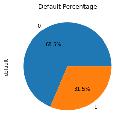

## Borrower Rate by Default

> The interest rate for this loan is known as the borrower's rate. According to the plot, defaulted loans are more likely to have high borrower rates.

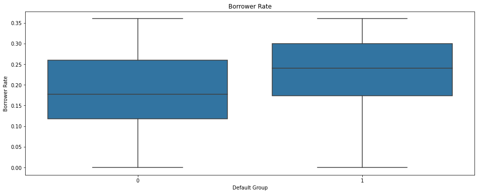

## Default Rate by Income Group

> The highest default rates come from *Not Employed group* and *\$0* group. Also, we also note that the *Not display* group's average default rate is lower than \$0 - \$49,999.

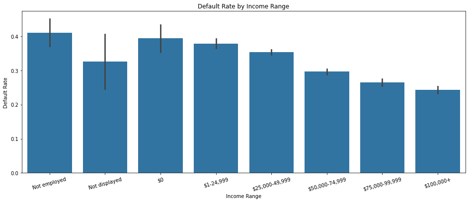

## Credit Score Range Lower by Default Rate

> The lower range of credit scores and default rate have a very significant negative link. There is an error at creditscorerangelower = 860, though.

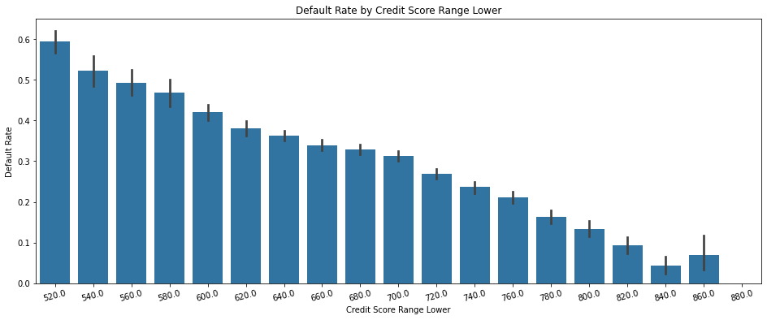

## Borrower Rate by Credit Score Range Lower & Default Rate

> The borrower rate for the default group is more likely to be greater for each credit score.

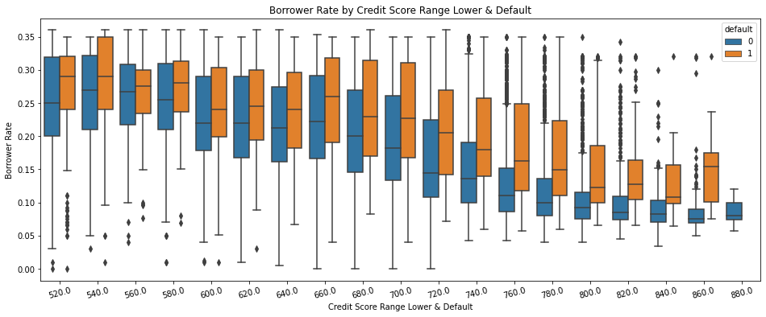